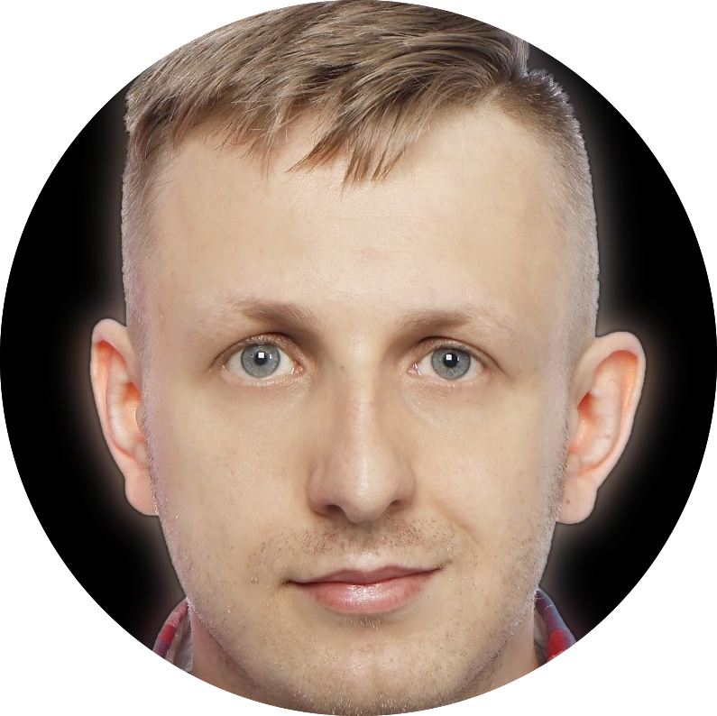

# Krzysztof Jończyk

## Profile

Dedicated database administrator with hands-on experience in DB2, MSSQL, and PostgreSQL environments, currently employed at Kyndryl. Skilled in database performance tuning, backup and recovery, and SQL query optimization. Motivated to transition into Data Engineering to apply my expertise in data management, scripting, and system optimization toward designing automated pipelines and cloud-based solutions. Passionate about learning modern tools such as Python, Docker, Kubernetes, and CI/CD to enhance data workflows and infrastructure efficiency.  
**Preferred work type: Remotely or Hybrid in Katowice, Kraków(Poland)**

## Work Experience

#### Kyndryl GSDC PL | Associate, Systems Administration

**03.2023 - PRESENT**

- Executing DB2 database restores with redirects, ensuring data integrity and disaster recovery readiness.
- Developing PDF guidance for standardized DB2 restore with redirect procedures.
- Organizing and performing DB2 instance and database upgrades from 11.1 to 11.5.
- Coordinating patching campaigns for servers hosting DB2 databases.
- Creating DB2 backups (single and multi-file) for operational continuity.
- Developing and executing DB2 scripts to automate routine administrative tasks.
- Supporting Oracle systems (including checking listeners, performing table import/export, and executing RMAN backups)
- Performing SQL Server patching and configured security parameters based on health checks.
- Managing and executing PostgreSQL database patching on specific servers.
- Fixing Health Checks according to Tech Spec on Database engine (DB2, MSSQL, Postgresql)

#### Kyndryl GSDC PL | Representative, Computer Operations

**09.2021 - 03.2023**

- Creating and executing Changes on SNOW tool
- Resolving incident tickets Speaking with internal customers
- Organizing patching campaign for servers with db2 database
- Operating of few tools like SNOW, Maximo, RCP Creating Tickets, Service Request on Maximo

#### IBM GSDC PL | IT Assistant

**07.2021 - 09.2021**

- Executing DB2 tasks (Cataloging/Uncataloging database)
- Decommisioning databases

#### RTV EURO AGD | Retail Customer Advisor

**10.2015 - 06.2021**

- Providing Customer service along with the selection of goods tailored to individual customer needs.
- Accepting complaints and deliveries along with a documentary analysis

## Education

Master of Data Science

**2019 - 2022**

Akademia WSB Dąbrowa Górnicza

GPA: 4.5

Bachelor of Software and database engineering

**2011 - 2015**

Akademia Górnośląska im. Wojciecha Korfantego - Katowice

GPA: 4.5

## Skills

- SQL
- RDBMS (Oracle/DB2 LUW/PostgreSQL/MSSQL)
- Python Language Basics
- Cloud Services (AWS, Microsoft Azure & Google)
- Containerization (Docker & Kubernetes)
- CI/CD (Jenkins, GitLab)
- VCS (Git)
- Microsoft Power Platform (Power BI, Power Automate, Power Apps)
- High-Availability Disaster Recovery (Pacemaker & TSAMP)
- Red Hat Enterprise Linux
- Maximo (ICD), SNOW, JIRA

## Certifications

- AWS CERTIFIED AI PRACTITIONER
- MICROSOFT DP-700 CERTIFICATION - FABRIC DATA ENGINEER ASSOCIATE
- AWS CERTIFIED DATA ENGINEER – ASSOCIATE
- KYNDRYL MICROSOFT CLOUD & AI BOOTCAMP CHALLENGE
- GOOGLE CLOUD DIGITAL LEADER
- MICROSOFT DP-300 CERTIFICATE
- MICROSOFT AZ-900 CERTIFICATE
- PYTHON FOR DATASCIENCE AND AIOPS
- AWS CERTIFIED CLOUD PRACTITIONER

## Languages

- English (B2)
- German (B2)
- Polish (C2)